# Introducción a la probabilidad

Técnicas Estadísticas y Análisis de Datos Climáticos

Victor Eduardo Diaz Romero

2024/09/21

# Probabilidad

[figure not shown]

## Experimento:

Un experimento consiste en la observación de un fenómeno ocurrido en la naturaleza. Pueden señalarse dos tipos de experimentos, a partir de la predictibilidad del resultado:

### 1. Experimento Determinista

Un experimento determinista es aquel que, una vez estudiado, podemos predecirlo (es fijo), es decir, que sabemos lo que sucederá antes de que ocurra.

Algunos ejemplos:

- Si tiramos una piedra al aire esta caerá.
- Si un coche que va a 100 km/h tarda en hacer un trayecto de 1 hora, tenemos la certeza de que ha recorrido 100 km.
- Si ponemos agua en el congelador sabemos que se congelará a 0º C.

Presión atmosférica teórica a diferentes alturas mediante la ecuación barométrica (Relación determinista entre la presión, altura y temperatura)

```r
# Datos meteorológicos
altura <- seq(0, 10000, by = 500)  # Altura en metros
temperatura_superficie <- 15  # Temperatura a nivel del mar en °C
presion_superficie <- 1013.25  # Presión atmosférica a nivel del mar en hPa
constante_lapse_rate <- 0.0065  # Tasa de cambio de temperatura con la altura
constante_gas_seco <- 287.06  # Constante del gas seco en J/(kg·K)
constante_gravedad <- 9.80667 # en m/s2

# Calcular la presión atmosférica en función de la altura utilizando la ecuación barométrica
temperatura <- temperatura_superficie - constante_lapse_rate * altura
presion <- presion_superficie * (1 - (constante_lapse_rate * altura) / (temperatura_superficie + 273.15))^(constante_gravedad / (constante_lapse_rate * constante_gas_seco))

# Gráfico de la presión atmosférica en función de la altura
#install.packages("ggplot2")
library(ggplot2)

df <- data.frame(altura, presion)
df
```

```
##    altura   presion
## 1       0 1013.2500
## 2     500  954.6097
## 3    1000  898.7481
## 4    1500  845.5634
## 5    2000  794.9564
## 6    2500  746.8304
## 7    3000  701.0912
## 8    3500  657.6471
## 9    4000  616.4091
## 10   4500  577.2904
## 11   5000  540.2066
## 12   5500  505.0758
## 13   6000  471.8182
## 14   6500  440.3566
## 15   7000  410.6156
## 16   7500  382.5225
## 17   8000  356.0063
## 18   8500  330.9986
## 19   9000  307.4327
## 20   9500  285.2441
## 21  10000  264.3705
```

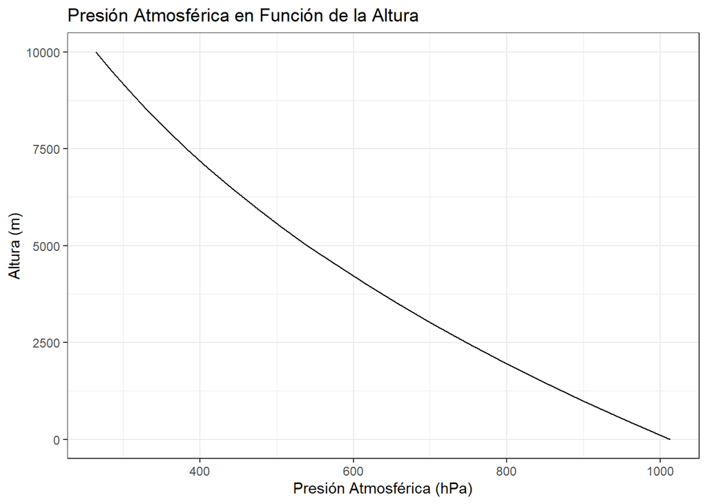

```r
ggplot(df, aes(x = presion, y = altura)) +
  geom_line() +
  labs(x = "Presión Atmosférica (hPa)", y = "Altura (m)") +
  ggtitle("Presión Atmosférica en Función de la Altura") +
  theme_bw()
```

### 2.Experimento aleatorio

Un experimento aleatorio es aquel cuyo resultado no se puede predecir, es decir, que por muchas veces que repitamos el experimento en igualdad de condiciones, no se conoce el resultado que se va a obtener. Por ejemplo: - Si lanzamos dos monedas no sabemos si saldrá cara o cruz. - Cuando sacamos una bola de una caja que contiene bolas de diferentes colores, no podemos predecir el color que obtendremos. - Si lanzamos un dado, no podemos predecir el número que saldrá.

### Espacio Muestral

Un espacio muestral (Ω) es el conjunto de todos los resultados posibles de un experimento aleatorio.

Ejemplos:

- Se lanzan dos monedas, entonces, el espacio muestral será Ω = {𝐶𝐶, 𝐶𝑆, 𝑆𝐶, 𝑆𝑆}, donde 𝐶 es la cara de una moneda y 𝑆, el sello.
- Se lanzan un dado, entonces, el espacio muestral será Ω = {1,2,3,4,5,6}

#### Suceso

Se conocen como eventos o sucesos a un subconjunto del espacio muestral o del resultado particular de un experimento aleatorio. Se los suele representar por las primeras letras del alfabeto.

Ejemplos:

- Evento A: Que salga un número par al lanzar un dado.
- Evento B: Que salga sello al lanzar una moneda.

#### Suceso elemental

Un Suceso Elemental es cada uno de los posibles resultados de un experimento aleatorio, es decir, cada uno de los elementos que forman parte del espacio muestral.

### Ejemplos:

#### Lanzar un dado:

```r
##Experimento aleatorio: Lanzar un dado
EA <- "Lanzar un dado"
EA
```

```
## [1] "Lanzar un dado"
```

```r
#Espacio muestral: todos los resultados del experimento aleatorio
EM <- c(1:6)
EM
```

```
## [1] 1 2 3 4 5 6
```

```r
#Suceso: Sale un número par
#%% obtiene el residuo de una división
S1 <- EM[EM %% 2 == 0]
S1
```

```
## [1] 2 4 6
```

```r
#Suceso: Sale un número impar
S2 <- EM[EM %% 2 != 0]
S2
```

```
## [1] 1 3 5
```

```r
#Suceso: Número mayor a 3
S3 <- EM[EM > 3]
S3
```

```
## [1] 4 5 6
```

```r
#Suceso elemental:
sample(EM,1)
```

```
## [1] 1
```

#### Obtener 4 bolas de una urna

Se tiene una urna con bolas de color de color roja, verde y azul, se quiere obtener 4.

```r
##Experimento aleatorio:
EA <- "Se tiene  una urna con bolas de color de color roja, verde y azul, se quiere obtener 4"
EA
```

```
## [1] "Se tiene  una urna con bolas de color de color roja, verde y azul, se quiere obtener 4"
```

```r
#Espacio muestral: todos los resultados del experimento aleatorio
EMU<-function(n){
  temp<-list()
  for (i in 1:n){
    temp[[i]]<-c("Rojo","Azul","Verde")
  }
  resultado<-expand.grid(temp)
  names(resultado)<-c(paste(rep("Bola",n),1:n,sep=""))
  return(resultado)
}
EMU(4)
```

```
##    Bola1 Bola2 Bola3 Bola4
## 1   Rojo  Rojo  Rojo  Rojo
## 2   Azul  Rojo  Rojo  Rojo
## 3  Verde  Rojo  Rojo  Rojo
## 4   Rojo  Azul  Rojo  Rojo
## 5   Azul  Azul  Rojo  Rojo
## 6  Verde  Azul  Rojo  Rojo
## 7   Rojo Verde  Rojo  Rojo
## 8   Azul Verde  Rojo  Rojo
## 9  Verde Verde  Rojo  Rojo
## 10  Rojo  Rojo  Azul  Rojo
## 11  Azul  Rojo  Azul  Rojo
## 12 Verde  Rojo  Azul  Rojo
## 13  Rojo  Azul  Azul  Rojo
## 14  Azul  Azul  Azul  Rojo
```

[output cut: 67 more lines]

```r
#Suceso: 3 primeras son rojas
S1 <-c(c("RRRA"),c("RRRR"),c("RRRV"))
S1
```

```
## [1] "RRRA" "RRRR" "RRRV"
```

```r
#Suceso elemental:
"RVAR"
```

```
## [1] "RVAR"
```

#### Tipo de día de mañana basado en la condición del cielo

```r
# Experimento aleatorio:
EA <- "Tipo de día de mañana basado en la condición del cielo"
EA
```

```
## [1] "Tipo de día de mañana basado en la condición del cielo"
```

```r
# Espacio muestral: todos los posibles resultados (diferentes condiciones del cielo)
EM <- c("Día Soleado", "Día Nublado", "Día Lluvioso", "Día Nevado")

# Suceso: día con precipitación
S1  <- c("Día Lluvioso", "Día Nevado")
S1
```

```
## [1] "Día Lluvioso" "Día Nevado"
```

```r
# Suceso elemental:
sample(EM, 1)
```

```
## [1] "Día Lluvioso"
```

## Probabilidad Clásica

Sea espacio muestral finito y supongamos que todos los eventos elementales suceden con la misma probabilidad. Entonces, para cada evento A: Donde A viene a ser un suceso

Regla de Laplace

P(A)=Número de elementos del suceso A / Número de elementos total del espacio muestral

```r
EA <- "Lanzar un dado"
EA
```

```
## [1] "Lanzar un dado"
```

```r
EM <- c(1:6)
EM
```

```
## [1] 1 2 3 4 5 6
```

```r
S1 <- EM[EM %% 2 == 0]
S1
```

```
## [1] 2 4 6
```

```r
P.S1 <- length(S1)/length(EM)
P.S1
```

```
## [1] 0.5
```

```r
##Experimento aleatorio:
EA <- "Se tiene  una urna con bolas de color de color roja, verde y azul, se quiere obtener 4"
EA
```

```
## [1] "Se tiene  una urna con bolas de color de color roja, verde y azul, se quiere obtener 4"
```

```r
#Espacio muestral: todos los resultados del experimento aleatorio
EMU<-function(n){
  temp<-list()
  for (i in 1:n){
    temp[[i]]<-c("Rojo","Azul","Verde")
  }
  resultado<-expand.grid(temp)
  names(resultado)<-c(paste(rep("Bola",n),1:n,sep=""))
  return(resultado)
}
EMU(4)
```

```
##    Bola1 Bola2 Bola3 Bola4
## 1   Rojo  Rojo  Rojo  Rojo
## 2   Azul  Rojo  Rojo  Rojo
## 3  Verde  Rojo  Rojo  Rojo
## 4   Rojo  Azul  Rojo  Rojo
## 5   Azul  Azul  Rojo  Rojo
## 6  Verde  Azul  Rojo  Rojo
## 7   Rojo Verde  Rojo  Rojo
## 8   Azul Verde  Rojo  Rojo
## 9  Verde Verde  Rojo  Rojo
## 10  Rojo  Rojo  Azul  Rojo
## 11  Azul  Rojo  Azul  Rojo
## 12 Verde  Rojo  Azul  Rojo
## 13  Rojo  Azul  Azul  Rojo
## 14  Azul  Azul  Azul  Rojo
```

[output cut: 67 more lines]

```r
#Suceso: 3 primeras son rojas
S1 <-c(c("RRRA"),c("RRRR"),c("RRRV"))
S1
```

```
## [1] "RRRA" "RRRR" "RRRV"
```

```r
P.S1 <- length(S1)/nrow(EMU(4))
P.S1
```

```
## [1] 0.03703704
```

```r
# Experimento aleatorio:
EA <- "Tipo de día de mañana basado en la condición del cielo"
EA
```

```
## [1] "Tipo de día de mañana basado en la condición del cielo"
```

```r
# Espacio muestral: todos los posibles resultados (diferentes condiciones del cielo)
EM <- c("Día Soleado", "Día Nublado", "Día Lluvioso", "Día Nevado")

# Suceso: día con precipitación
S1  <- c("Día Lluvioso", "Día Nevado")
S1
```

```
## [1] "Día Lluvioso" "Día Nevado"
```

```r
P.S1 <- length(S1)/length(EM)
```

## Axiomas de la probabilidad

### No negatividad

Probabilidad de cualquier evento A debe ser un número entre 0 y 1, es decir: 0≤P(A)≤1

-Probabilidad 0: Indica que el evento es imposible. -Probabilidad 1: Indica que el evento es seguro.

```r
# Probabilidad de que llueva hoy
prob_lluvia <- 0.3
print(prob_lluvia)  # Resultado: 0.3 (≥ 0)
```

```
## [1] 0.3
```

### Unidad:

La probabilidad del espacio muestral completo es 1.En un día dado, algún estado del clima debe ocurrir (soleado, nublado, lluvioso, etc.). La suma de las probabilidades de todos los eventos posibles es igual a 1.

P(S) =1

```r
# Probabilidades de diferentes estados del clima
prob_soleado <- 0.5
prob_nublado <- 0.3
prob_lluvioso <- 0.2

# Suma total de probabilidades
prob_total <- prob_soleado + prob_nublado + prob_lluvioso
print(prob_total)  # Resultado: 1
```

```
## [1] 1
```

### Complemento de un evento:

La probabilidad de que un evento no ocurra es igual a 1 menos la probabilidad de que ocurra.

P(Ac)=1−P(A)

```r
# Probabilidad de que llueva
prob_lluvia <- 0.3

# Probabilidad de que no llueva
prob_no_lluvia <- 1 - prob_lluvia
print(prob_no_lluvia)  # Resultado: 0.7
```

```
## [1] 0.7
```

### Unión de eventos:

Para dos eventos cualquiera A y B, la probabilidad de la unión de estos dos eventos es la suma de sus probabilidades menos la intersección, es decir

P(AUB) = P(A) + P(B) - P(AnB)

```r
# Probabilidad de lluvia (A) y probabilidad de viento fuerte (B)
prob_lluvia <- 0.40
prob_viento <- 0.30

# Probabilidad de que ocurra tanto lluvia como viento (intersección)
prob_lluvia_y_viento <- 0.15

# Calculamos la probabilidad de que ocurra lluvia o viento
prob_lluvia_o_viento <- prob_lluvia + prob_viento - prob_lluvia_y_viento
print(paste("Probabilidad de lluvia o viento:", prob_lluvia_o_viento))
```

```
## [1] "Probabilidad de lluvia o viento: 0.55"
```

## Variable aleatoria

Una variable aleatoria es una función que asigna un número real a cada resultado en el espacio muestral de un experimento aleatorio. En otras palabras, es una variable que toma valores numéricos en función de los resultados de un experimento aleatorio

OJO: a diferencia del espacio muestral que consideraba los posibles resultados, aquí se toman todos los resultados que se dan durante un periodo.

Algunos ejemplos son: número de caras obtenidas al lanzar seis veces una moneda, número de llamadas que recibe un teléfono durante una hora, tiempo de fallo de una componente eléctrica, número de heladas durante un año.

Ejemplo:

```r
# Simulación de datos de temperatura mínima (ejemplo)
set.seed(123)
#media, mediana y moda al centro
temperaturas_minimas <- rnorm(365, mean = 5, sd = 3)  # Temperaturas mínimas diarias en grados Celsius
length(temperaturas_minimas)
```

```
## [1] 365
```

```r
library(ggplot2)
mean(temperaturas_minimas)
```

```
## [1] 5.095616
```

```r
median(temperaturas_minimas)
```

```
## [1] 4.900892
```

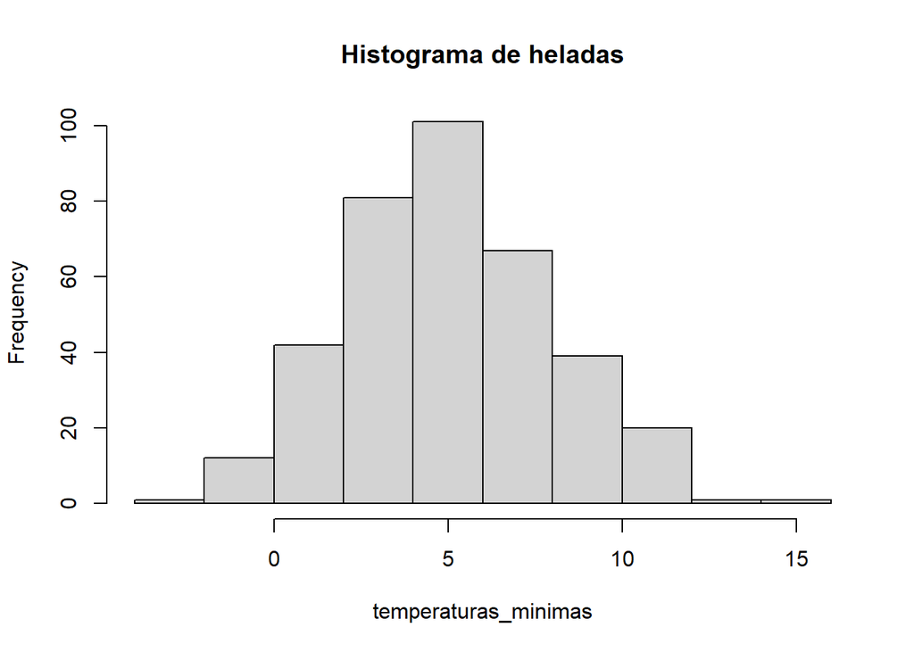

```r
hist(temperaturas_minimas ,main="Histograma de heladas",freq=T)
```

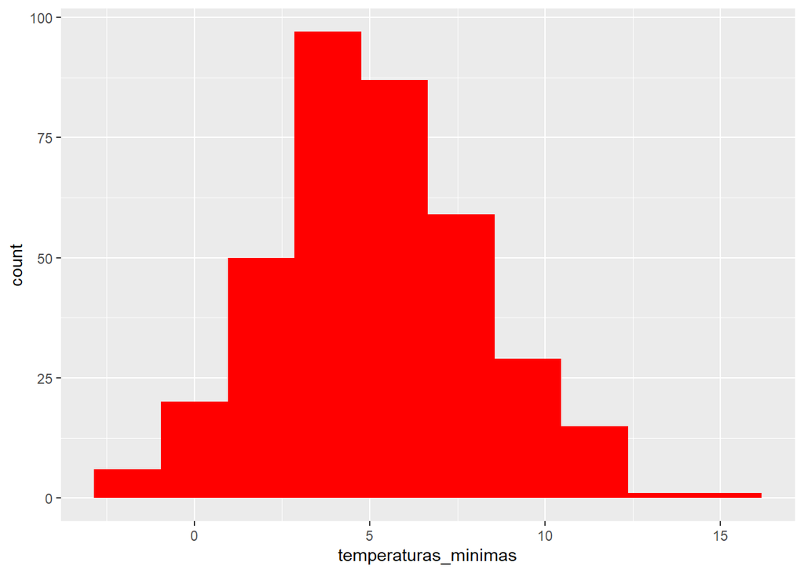

```r
###ggplot solo trabaja con tabla de datos o data.frame
ggplot(data.frame(temperaturas_minimas) , aes(x = temperaturas_minimas)) +
  geom_histogram(fill="red",bins=10)
```

```r
# Calcular la probabilidad de heladas (temperatura mínima < 0°C)
dias_con_heladas <- sum(temperaturas_minimas < 0)
total_dias <- length(temperaturas_minimas)
probabilidad_heladas <- dias_con_heladas / total_dias
```

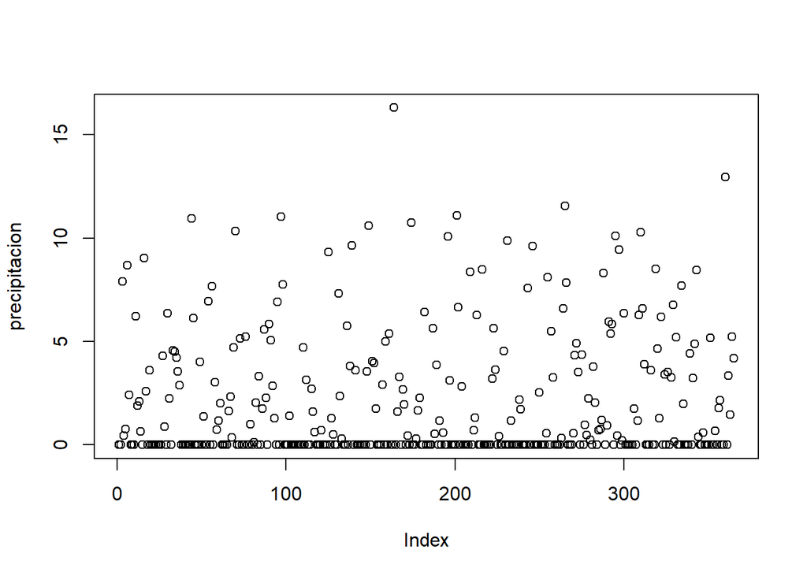

```r
# Simulación de datos de precipitación histórica (ejemplo)
set.seed(123)  # Establecer semilla para reproducibilidad
precipitacion <- rnorm(365, mean = 0.1, sd = 5)  # Datos de precipitación en mm para un año
precipitacion[precipitacion < 0] <- 0

plot(precipitacion)
```

```r
# Calcular la probabilidad de lluvia
dias_con_lluvia <- sum(precipitacion > 0)
total_dias <- length(precipitacion)
probabilidad_lluvia <- dias_con_lluvia / total_dias
probabilidad_lluvia
```

```
## [1] 0.4958904
```